# SSRD FEM Data

2026-03-24

```r
library(readr)
FEM_Data <- read_csv("FEM Data.csv")
```

```r
PondoMPB_Data <- FEM_Data %>%
  filter(HOST == "ponderosa pine", DCA_COMMON_NAME == "mountain pine beetle", DAMAGE_TYPE == "Mortality") %>%
  mutate(
    SURVEY_YEAR = as.numeric(SURVEY_YEAR),
    ACRES = as.numeric(ACRES),
    PERCENT_MID = as.numeric(PERCENT_MID)
  ) %>%
  select(-CREATED_DATE, -MODIFIED_DATE,
    -FEATURE_USER_ID, -OBSERVATION_USER_ID,
    -NOTES, -COLLECTION_MODE,
    -SNAPGRID_ROW, -SNAPGRID_COLUMN, -HOST_GROUP, -HOST_GROUP_CODE, -PERCENT_AFFECTED_CODE, -LABEL, -matches("^X_clim_.*(min|max|count|sum)$"))
```

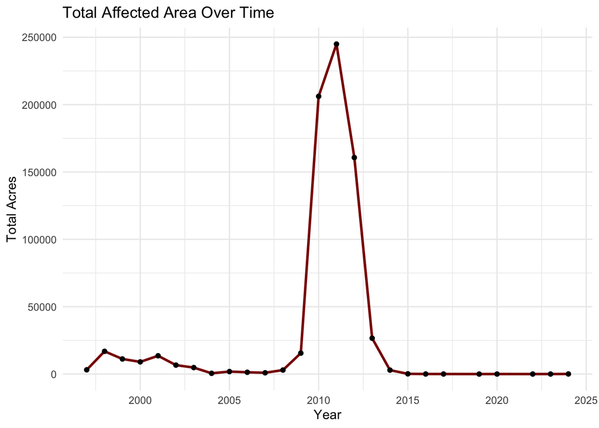

```r
total_affected <- PondoMPB_Data %>%
  group_by(SURVEY_YEAR) %>%
  summarise(total_acres = sum(ACRES, na.rm = TRUE)) %>%
  ggplot(aes(x = SURVEY_YEAR, y = total_acres)) +
  geom_line(color = "darkred", linewidth = 1) +
  geom_point() +
  labs(title = "Total Affected Area Over Time",
       x = "Year", y = "Total Acres") +
  theme_minimal()

total_affected
```

**Summary**

- shows how the total area of forest affected by mortality changes over time

- each point represents the summed acres impacted in a given survey year

- line highlights trends in outbreak dynamics

- huge spike and then it flat lines (which may be due to lack of data)

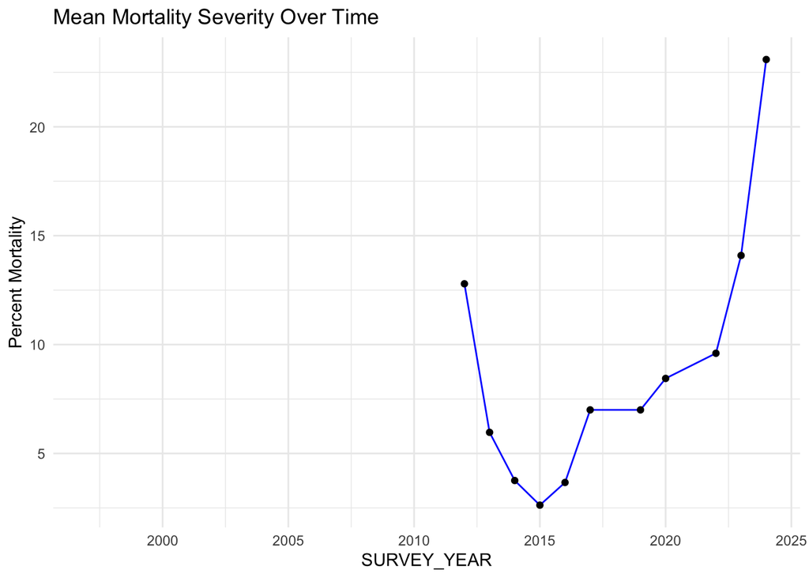

```r
mortality <- PondoMPB_Data %>%
  group_by(SURVEY_YEAR) %>%
  summarise(mean_mortality = mean(PERCENT_MID, na.rm = TRUE)) %>%
  ggplot(aes(SURVEY_YEAR, mean_mortality)) +
  geom_line(color = "blue") +
  geom_point() +
  labs(title = "Mean Mortality Severity Over Time",
       y = "Percent Mortality") +
  theme_minimal()
mortality
```

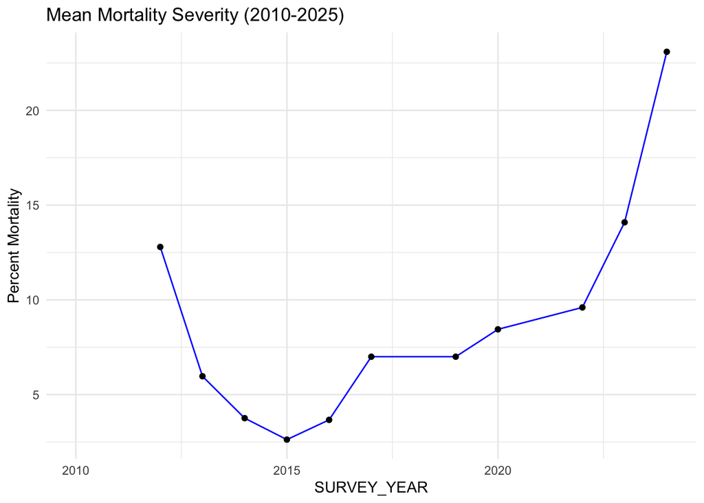

```r
mortality <- PondoMPB_Data %>%
  filter(SURVEY_YEAR >= 2010 & SURVEY_YEAR <= 2025) %>%
  group_by(SURVEY_YEAR) %>%
  summarise(mean_mortality = mean(PERCENT_MID, na.rm = TRUE)) %>%
  ggplot(aes(x = SURVEY_YEAR, y = mean_mortality)) +
  geom_line(color = "blue") +
  geom_point() +
  labs(title = "Mean Mortality Severity (2010-2025)",
       y = "Percent Mortality") +
  theme_minimal()

mortality
```

**Summary**

- average mortality severity of ponderosa pines from 2010 to 2025

- highlights year-to-year trends, whether the outbreak was intensifying, stabilizing, or declining during that period

- shape looks decent

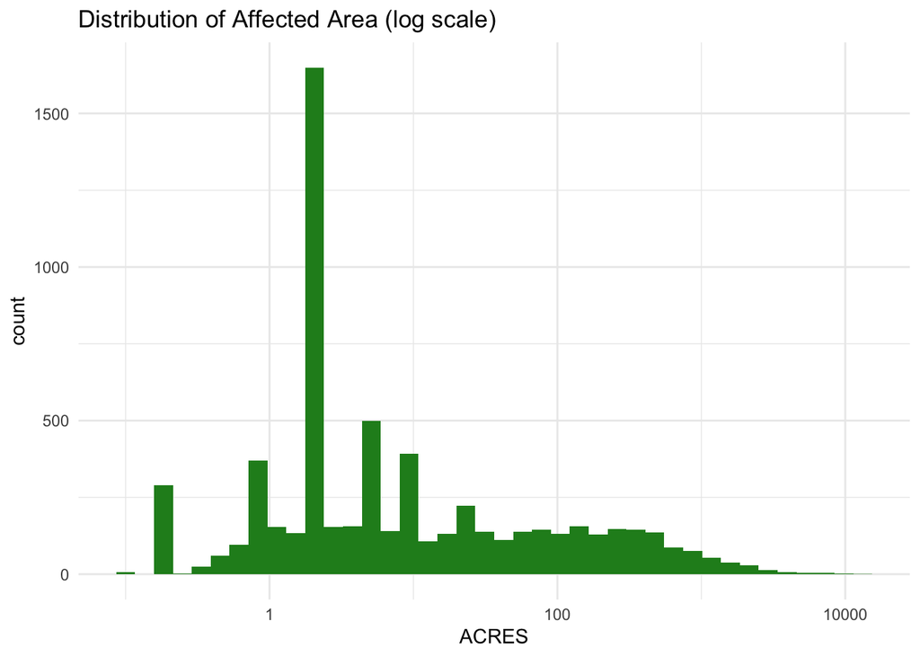

```r
ggplot(PondoMPB_Data, aes(x = ACRES)) +
  geom_histogram(bins = 40, fill = "forestgreen") +
  scale_x_log10() +
  labs(title = "Distribution of Affected Area (log scale)") +
  theme_minimal()
```

**Summary** - distribution of individual affected areas across all observations - log scale to account for the wide range of sizes - reveals that most mortality events impact relatively small areas

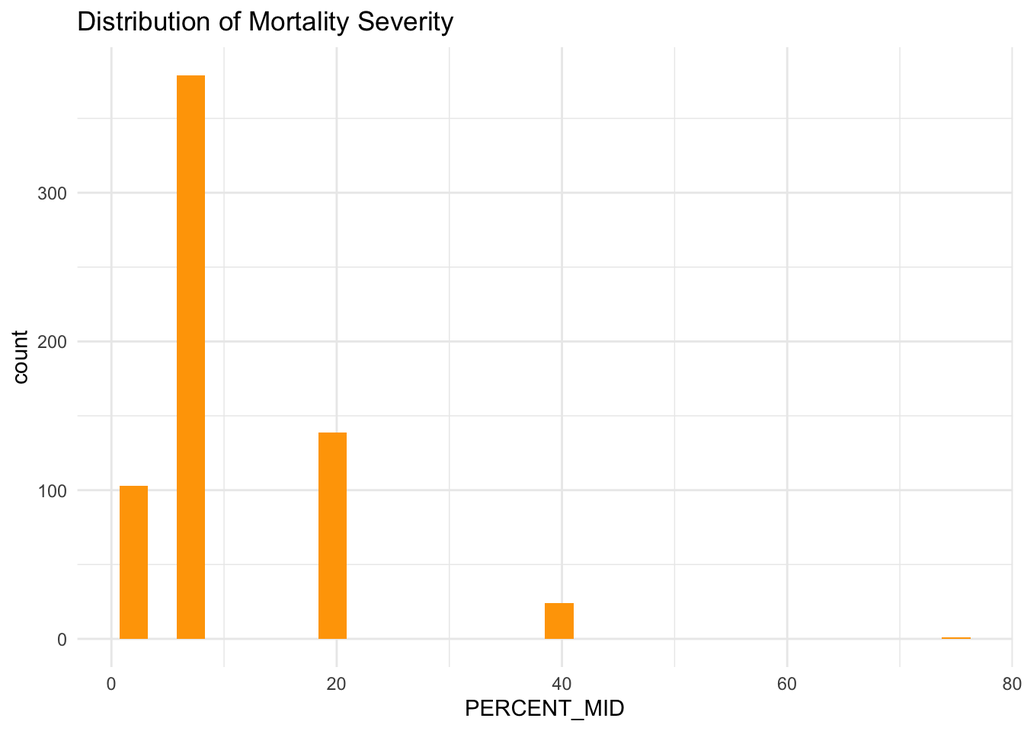

```r
ggplot(PondoMPB_Data, aes(x = PERCENT_MID)) +
  geom_histogram(bins = 30, fill = "orange") +
  labs(title = "Distribution of Mortality Severity") +
  theme_minimal()
```

```r
# Percent Mid = Affected range mid point
```

**Summary**

- shows how mortality severity (PERCENT_MID) is distributed

- indicates that most observations have low to moderate mortality

- high-severity events are less common

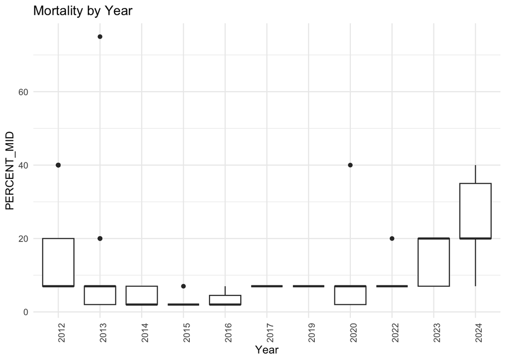

```r
ggplot(PondoMPB_Data %>% filter(!is.na(PERCENT_MID)),
       aes(x = factor(SURVEY_YEAR), y = PERCENT_MID)) +
  geom_boxplot() +
  labs(title = "Mortality by Year",
       x = "Year") +
  theme_minimal() +
  theme(axis.text.x = element_text(angle = 90))
```

**summary**

- something feels wrong here but we still have the right trend

- distribution of mortality severity each year

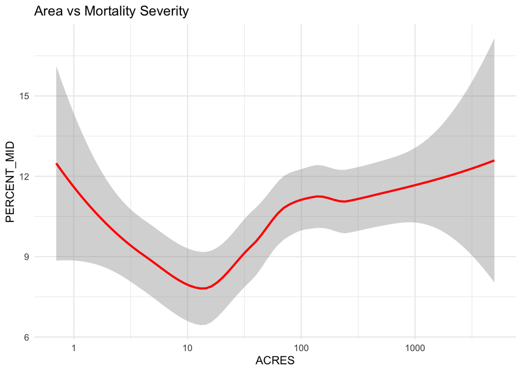

```r
ggplot(PondoMPB_Data, aes(x = ACRES, y = PERCENT_MID)) +
  scale_x_log10() +
  geom_smooth(method = "loess", color = "red") +
  labs(title = "Area vs Mortality Severity") +
  theme_minimal()
```

**Summary**

- relationship between the size of affected areas (log-scaled) and mortality severity

- red curve = in general, larger affected areas tend to be associated with slightly higher mortality

- relationship is nonlinear and variable

```r
climate_vars <- names(PondoMPB_Data) %>%
  stringr::str_subset("^X_clim_.*mean$")

correlations <- sapply(PondoMPB_Data[climate_vars], function(x) {
  cor(x, PondoMPB_Data$PERCENT_MID, use = "complete.obs")
})

sort(correlations, decreasing = TRUE)
```

```
## X_clim_dat16mean X_clim_dat20mean X_clim_dat14mean X_clim_dat06mean
##     0.1417356297     0.1371573566     0.0733392693     0.0669025992
## X_clim_dat18mean X_clim_dat10mean X_clim_dat17mean X_clim_dat19mean
##     0.0665935723     0.0608400466     0.0553673308     0.0442812967
## X_clim_dat13mean X_clim_dat11mean X_clim_dat01mean X_clim_dat00mean
##     0.0406649793     0.0387386899     0.0290067798     0.0255338587
## X_clim_dat12mean X_clim_dat02mean X_clim_dat34mean X_clim_dat15mean
##     0.0210697003     0.0166701455     0.0132371747     0.0123502873
## X_clim_dat05mean X_clim_dat04mean X_clim_dat03mean X_clim_dat08mean
##     0.0099324855     0.0003554602    -0.0018100770    -0.0033275376
## X_clim_dat22mean X_clim_dat07mean X_clim_dat09mean X_clim_dat21mean
##    -0.0051046755    -0.0141663567    -0.0368578236    -0.0475481218
## X_clim_dat98mean X_clim_dat99mean X_clim_dat97mean X_clim_dat23mean
##    -0.0656301383    -0.1079669976    -0.1428124624    -0.1474199973
```

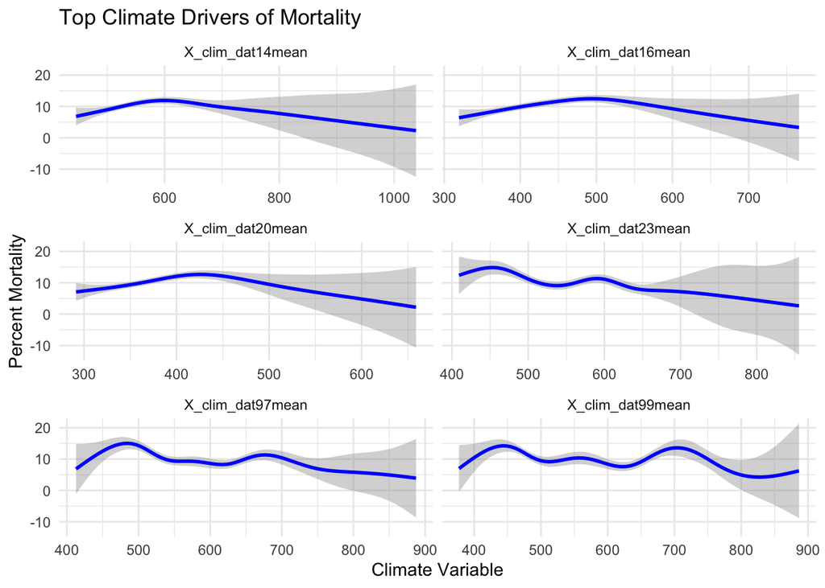

```r
top_vars <- names(sort(abs(correlations), decreasing = TRUE))[1:6]

df_top <- PondoMPB_Data %>%
  pivot_longer(
    cols = all_of(top_vars),
    names_to = "climate_var",
    values_to = "climate_value"
  )

ggplot(df_top, aes(x = climate_value, y = PERCENT_MID)) +
  geom_smooth(method = "gam", formula = y ~ s(x), color = "blue") +
  facet_wrap(~ climate_var, scales = "free_x", ncol = 2) +
  theme_minimal() +
  labs(
    title = "Top Climate Drivers of Mortality",
    x = "Climate Variable",
    y = "Percent Mortality"
  )
```

**Summary**

- six climate variables most strongly correlated with mortality

- I hate these climate variables and have no idea what they mean

- each panel represents one of the 6

- GAM smoothed

- mortality responds differently across the range of each climate driver

```r
climate_vars <- PondoMPB_Data %>%
  select(starts_with("X_clim")) %>%
  select(where(is.numeric))

cor_mat <- cor(climate_vars, use = "complete.obs")

library(reshape2)
```

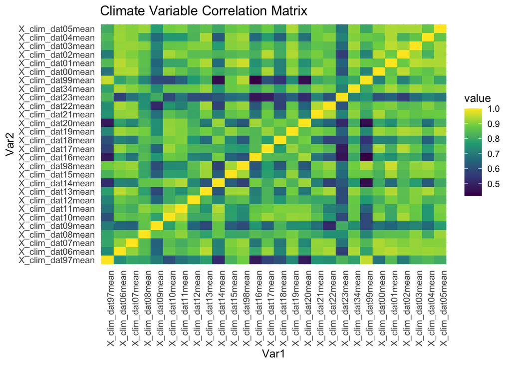

```r
cor_df <- melt(cor_mat)

ggplot(cor_df, aes(Var1, Var2, fill = value)) +
  geom_tile() +
  scale_fill_viridis_c() +
  theme_minimal() +
  theme(axis.text.x = element_text(angle = 90)) +
  labs(title = "Climate Variable Correlation Matrix")
```

**Summary**

- pairwise correlations among all mean numeric climate variables

- colors = strength and direction

- I know the axis suck I can make them better if I have better names for the climate variables

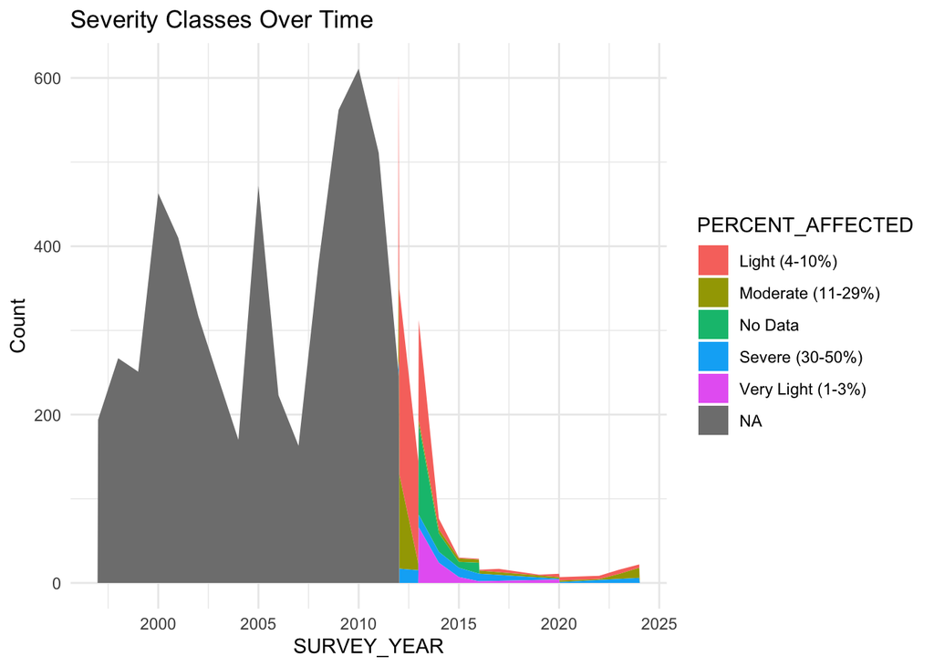

```r
severity_overtime <- PondoMPB_Data %>%
  count(SURVEY_YEAR, PERCENT_AFFECTED) %>%
  ggplot(aes(x = SURVEY_YEAR, y = n, fill = PERCENT_AFFECTED)) +
  geom_area() +
  labs(title = "Severity Classes Over Time",
       y = "Count") +
  theme_minimal()
severity_overtime
```

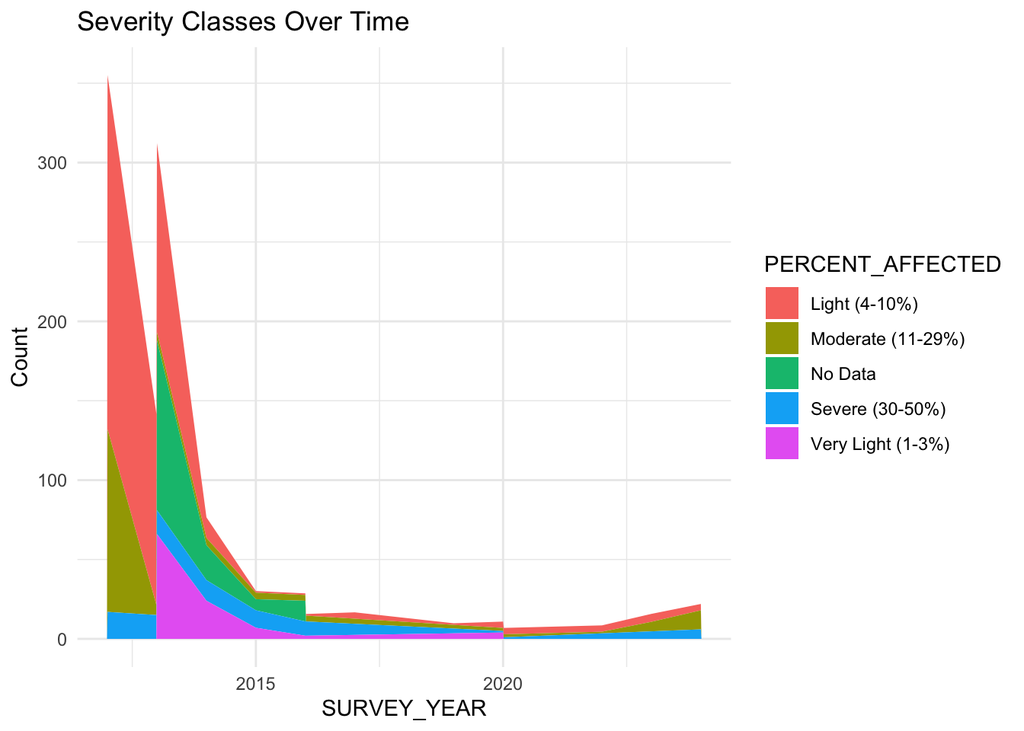

```r
severity_overtime_zoom <- PondoMPB_Data %>%
  filter(!is.na(PERCENT_AFFECTED),
         PERCENT_AFFECTED != "") %>%
  count(SURVEY_YEAR, PERCENT_AFFECTED) %>%
  ggplot(aes(x = SURVEY_YEAR, y = n, fill = PERCENT_AFFECTED)) +
  geom_area() +
  labs(title = "Severity Classes Over Time",
       y = "Count") +
  theme_minimal()
severity_overtime_zoom
```

**Summary:**

- how number of observations in each mortality severity class changes over time

- I zoomed in on just the part we have the right data for to make it readable and look prettier

- I think with the rest of our data these trends make sense

# Modeling

```r
lm_data <- PondoMPB_Data %>%
  select(PERCENT_MID, all_of(top_vars)) %>%
  filter(!is.na(PERCENT_MID)) %>%
  drop_na()

lm_model <- lm(PERCENT_MID ~ ., data = lm_data)
summary(lm_model)
```

```
##
## Call:
## lm(formula = PERCENT_MID ~ ., data = lm_data)
##
## Residuals:
##     Min      1Q  Median      3Q     Max
## -13.639  -4.570  -2.005   4.287  61.168
##
## Coefficients:
##                   Estimate Std. Error t value Pr(>|t|)
## (Intercept)      20.222591   4.064856   4.975  8.4e-07 ***
## X_clim_dat23mean -0.013792   0.012455  -1.107  0.26859
## X_clim_dat97mean -0.058841   0.019522  -3.014  0.00268 **
## X_clim_dat16mean  0.041687   0.017139   2.432  0.01528 *
## X_clim_dat20mean  0.008343   0.024566   0.340  0.73427
## X_clim_dat99mean  0.032539   0.013240   2.458  0.01425 *
## X_clim_dat14mean -0.012534   0.016849  -0.744  0.45719
## ---
## Signif. codes:  0 '***' 0.001 '**' 0.01 '*' 0.05 '.' 0.1 ' ' 1
##
## Residual standard error: 8.41 on 639 degrees of freedom
## Multiple R-squared:  0.08975,    Adjusted R-squared:  0.0812
## F-statistic:  10.5 on 6 and 639 DF,  p-value: 3.961e-11
```

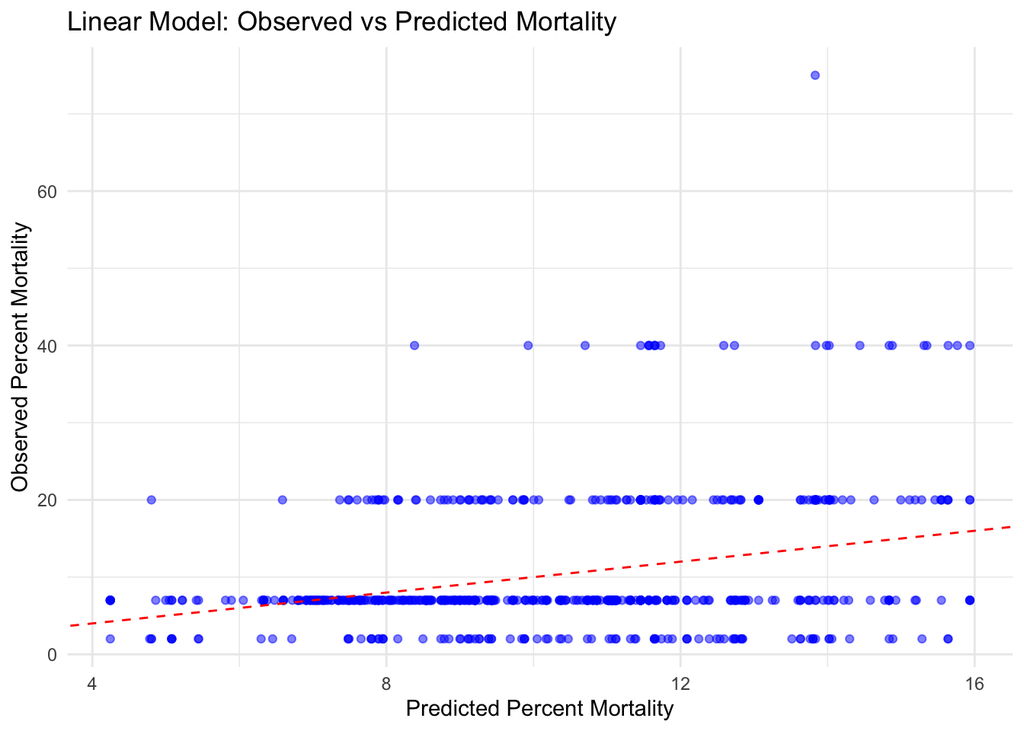

```r
lm_data$predicted <- predict(lm_model, newdata = lm_data)

ggplot(lm_data, aes(x = predicted, y = PERCENT_MID)) +
  geom_point(alpha = 0.5, color = "blue") +
  geom_abline(intercept = 0, slope = 1, color = "red", linetype = "dashed") +
  labs(title = "Linear Model: Observed vs Predicted Mortality",
       x = "Predicted Percent Mortality",
       y = "Observed Percent Mortality") +
  theme_minimal()
```

[figure not shown]

```r
ggplot(lm_data, aes(x = predicted, y = PERCENT_MID)) +
  geom_abline(intercept = 0, slope = 1, color = "red", linetype = "dashed") +
  labs(title = "Linear Model: Observed vs Predicted Mortality",
       x = "Predicted Percent Mortality",
       y = "Observed Percent Mortality") +
  theme_minimal()
```

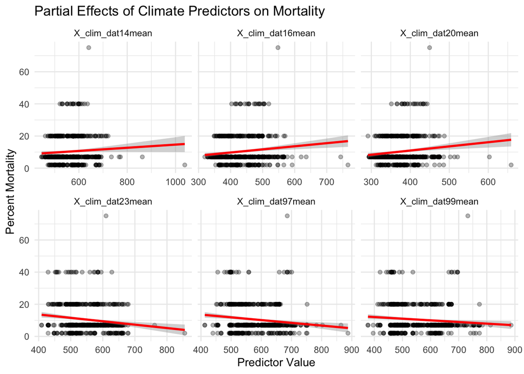

```r
lm_long <- lm_data %>%
  pivot_longer(cols = all_of(top_vars), names_to = "predictor", values_to = "value")

ggplot(lm_long, aes(x = value, y = PERCENT_MID)) +
  geom_point(alpha = 0.3) +
  geom_smooth(method = "lm", color = "red") +
  facet_wrap(~ predictor, scales = "free_x") +
  labs(title = "Partial Effects of Climate Predictors on Mortality",
       x = "Predictor Value", y = "Percent Mortality") +
  theme_minimal()
```

```r
gam_model <- gam(PERCENT_MID ~ s(X_clim_dat23mean) + s(X_clim_dat97mean) +
                   s(X_clim_dat16mean) + s(X_clim_dat20mean) +
                   s(X_clim_dat99mean) + s(X_clim_dat14mean),
                 data = PondoMPB_Data,
                 method = "REML",
                 na.action = na.omit)

summary(gam_model)
```

```
##
## Family: gaussian
## Link function: identity
##
## Formula:
## PERCENT_MID ~ s(X_clim_dat23mean) + s(X_clim_dat97mean) + s(X_clim_dat16mean) +
##     s(X_clim_dat20mean) + s(X_clim_dat99mean) + s(X_clim_dat14mean)
##
## Parametric coefficients:
##             Estimate Std. Error t value Pr(>|t|)
## (Intercept)  10.3313     0.3252   31.77   <2e-16 ***
## ---
## Signif. codes:  0 '***' 0.001 '**' 0.01 '*' 0.05 '.' 0.1 ' ' 1
##
## Approximate significance of smooth terms:
##                       edf Ref.df     F p-value
## s(X_clim_dat23mean) 4.413  5.402 2.841 0.03356 *
## s(X_clim_dat97mean) 1.001  1.001 6.692 0.00989 **
## s(X_clim_dat16mean) 1.001  1.002 5.519 0.01902 *
## s(X_clim_dat20mean) 1.001  1.002 1.557 0.21233
## s(X_clim_dat99mean) 3.261  4.138 2.816 0.02347 *
## s(X_clim_dat14mean) 2.324  2.923 1.667 0.22089
## ---
## Signif. codes:  0 '***' 0.001 '**' 0.01 '*' 0.05 '.' 0.1 ' ' 1
##
## R-sq.(adj) =  0.113   Deviance explained = 13.1%
## -REML = 2281.7  Scale est. = 68.308    n = 646
```

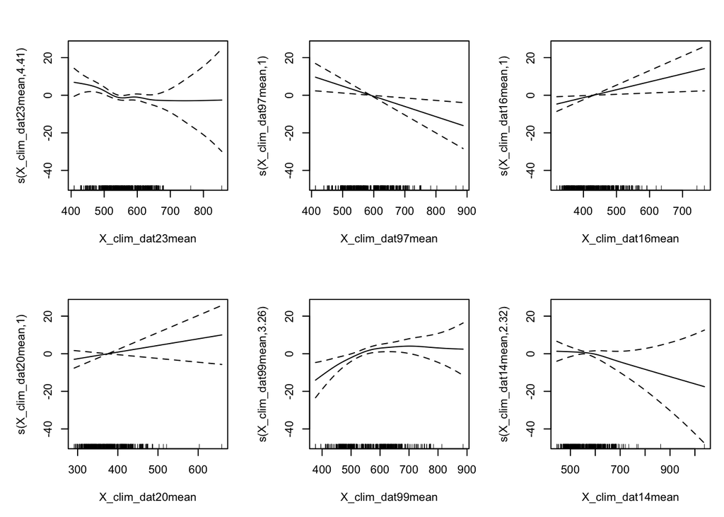

```r
par(mfrow = c(2, 3), mar = c(5, 5, 3, 2))
plot(gam_model, rug = TRUE, shade = TRUE, pages = 1)
```